# Linkage Mapping and QTL Analysis for Plant Height in a Maize Recombinant Inbred Line Population Derived from the Nested Association Mapping Panel

## 8.7 Interval Mapping

```r
# IM needs genotype probabilities at every position along the map,
# not just at the markers themselves - calc.genoprob() does this
# using the flanking markers and the Kosambi distances already in
# z020
#
# step = 1 -> a probability calculated every 1 cM, on top of the
# marker positions, ~1550 testing positions across the ~1549 cM map
#
# riself means only 2 QTL genotype classes possible at any position
# (NC350/NC350 or B73/B73) - simpler than the backcross/F2 cases with
# 2-4 classes

z020 <- calc.genoprob(z020, step = 1)

cat("Genotype probabilities calculated.\n")
```

```
## Genotype probabilities calculated.
```

```r
cat("Step size: 1 cM\n")
```

```
## Step size: 1 cM
```

```r
cat("Number of chromosomes:", nchr(z020), "\n")
```

```
## Number of chromosomes: 10
```

```r
cat("Total map length (cM):", round(sum(sapply(pull.map(z020), max)), 1), "\n")
```

```
## Total map length (cM): 1548.7
```

```r
# scanone() at every genoprob position, fitting plant height against
# QTL genotype prob and recording LOD - running both:
#
#   em : exact ML via Expectation-Maximization, slower, the gold
#        standard hk is approximating
#   hk : Haley-Knott regression, fast least-squares approximation,
#        holds up well with moderate missing data and decent marker
#        spacing
#
# if em and hk profiles match closely, that's good evidence the
# result isn't an artefact of the estimation method chosen

z020.em <- scanone(z020, pheno.col = "PlantHeight", method = "em")
cat("EM scan complete.\n")
```

```
## EM scan complete.
```

```r
z020.hk <- scanone(z020, pheno.col = "PlantHeight", method = "hk")
cat("HK scan complete.\n\n")
```

```
## HK scan complete.
```

```r
cat("--- Top position, EM method ---\n")
```

```
## --- Top position, EM method ---
```

```r
print(z020.em[which.max(z020.em$lod), ])
```

```
##           chr pos      lod
## c6.loc108   6 108 7.337647
```

```r
cat("\n--- Top position, HK method ---\n")
```

```
##
## --- Top position, HK method ---
```

```r
print(z020.hk[which.max(z020.hk$lod), ])
```

```
##           chr pos      lod
## c6.loc108   6 108 7.377878
```

```r
save(z020.em, z020.hk, file = "data/im_scanone.RData")
cat("\nSaved to data/im_scanone.RData\n")
```

```
##
## Saved to data/im_scanone.RData
```

```r
# permutation test for the genome-wide significance threshold -
# shuffle PlantHeight across individuals 1000 times, breaking the
# real genotype-phenotype link, keep the single highest LOD from each
# shuffled scan. 95th percentile of those 1000 max LODs = alpha 0.05
# threshold
#
# running both methods to match what gets compared later:
#   hk : fast, runs directly
#   em : slow on a 1549 cM map x 1000 perms, cached to disk so a
#        session restart doesn't mean starting over
#
# set.seed() so both runs are reproducible if re-run

set.seed(678)
z020.perm.hk <- scanone(
  z020,
  pheno.col = "PlantHeight",
  method    = "hk",
  n.perm    = 1000,
  verbose   = FALSE
)
cat("HK permutations complete.\n")
```

```
## HK permutations complete.
```

```r
rdata_perm_em <- "data/im_perm_em.RData"

if (file.exists(rdata_perm_em)) {

  load(rdata_perm_em)
  cat("Loaded cached EM permutation results from:", rdata_perm_em, "\n")

} else {

  cat("Running 1000 EM permutations. This will take a while.\n")
  cat("R will save the result automatically when done.\n")

  set.seed(678)
  z020.perm.em <- scanone(
    z020,
    pheno.col = "PlantHeight",
    method    = "em",
    n.perm    = 1000,
    verbose   = FALSE
  )

  save(z020.perm.em, file = rdata_perm_em)
  cat("EM permutations complete. Saved to:", rdata_perm_em, "\n")
}
```

```
## Loaded cached EM permutation results from: data/im_perm_em.RData
```

```r
cat("\n--- LOD threshold at alpha = 0.05 ---\n")
```

```
##
## --- LOD threshold at alpha = 0.05 ---
```

```r
cat("HK method:\n")
```

```
## HK method:
```

```r
print(summary(z020.perm.hk, alpha = 0.05))
```

```
## LOD thresholds (1000 permutations)
##     lod
## 5% 2.79
```

```r
cat("EM method:\n")
```

```
## EM method:
```

```r
print(summary(z020.perm.em, alpha = 0.05))
```

```
## LOD thresholds (1000 permutations)
##     lod
## 5% 2.99
```

```r
save(z020.perm.hk, z020.perm.em,
     file = "data/im_perm_both.RData")
cat("\nBoth permutation objects saved to data/im_perm_both.RData\n")
```

```
##
## Both permutation objects saved to data/im_perm_both.RData
```

```r
# summary() with perms= returns only positions clearing the
# permutation threshold at the chosen alpha - one row per peak
#
# note: summary() on a scanone perm object returns a named numeric
# vector, so pulling the threshold needs ["lod"], not $lod

thres_em <- summary(z020.perm.em, alpha = 0.05)["lod"]
thres_hk <- summary(z020.perm.hk, alpha = 0.05)["lod"]

cat("=== Significant QTL positions from Interval Mapping ===\n\n")
```

```
## === Significant QTL positions from Interval Mapping ===
```

```r
cat("--- EM method (threshold LOD =", round(thres_em, 2), ") ---\n")
```

```
## --- EM method (threshold LOD = NA ) ---
```

```r
print(summary(z020.em, perms = z020.perm.em, alpha = 0.05))
```

```
##            chr   pos  lod
## c4.loc67     4  67.0 4.75
## PZA02941.7   5  14.9 3.20
## c6.loc108    6 108.0 7.34
## c10.loc108  10 108.0 3.29
```

```r
cat("\n--- HK method (threshold LOD =", round(thres_hk, 2), ") ---\n")
```

```
##
## --- HK method (threshold LOD = NA ) ---
```

```r
print(summary(z020.hk, perms = z020.perm.hk, alpha = 0.05))
```

```
##            chr   pos  lod
## c4.loc67     4  67.0 4.61
## PZA02941.7   5  14.9 3.18
## c6.loc108    6 108.0 7.38
## c10.loc107  10 107.0 3.28
```

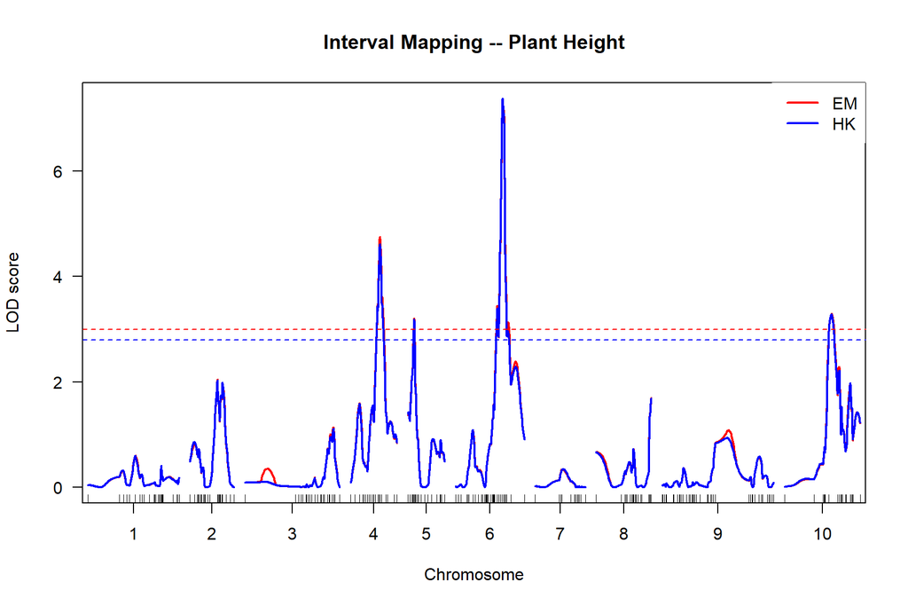

Figure 11. Interval mapping LOD profiles across the genome, comparing the EM (red) and HK (blue) methods. Dashed lines mark each method’s genome-wide significance threshold.

```r
# overlaying em and hk LOD profiles plus their thresholds - should
# sit almost on top of each other, any visible gap is where missing
# genotype data makes the hk approximation drift slightly from the
# exact em solution

plot(
  z020.em, z020.hk,
  ylab  = "LOD score",
  main  = "Interval Mapping -- Plant Height",
  col   = c("red", "blue"),
  lwd   = 2
)

add.threshold(z020.em, perms = z020.perm.em, col = "red",   lty = 2)
add.threshold(z020.hk, perms = z020.perm.hk, col = "blue",  lty = 2)

legend(
  "topright",
  legend  = c("EM", "HK"),
  lty     = 1,
  lwd     = 2,
  col     = c("red", "blue"),
  box.col = NA
)
```

```r
# fitqtl() at the IM peak (LG6, 108 cM), using multiple imputation
# so the effect estimate is attributed to the inferred QTL position
# rather than whichever marker happens to be nearest
#
# re-running sim.geno() with step = 1 here to match the IM grid - the
# earlier sim.geno() call used step = 0 for SMA and that draw set
# doesn't apply to interval positions
#
# riself -> fitqtl() fits 2 classes (NC350/NC350 vs B73/B73), and the
# additive effect it reports is HALF the homozygote difference -
# different convention to the lm() effect from SMA, which is the
# FULL difference. multiply fitqtl's estimate by 2 to compare the two

z020 <- sim.geno(z020, n.draws = 32, step = 1)

im_top_chr <- 6
im_top_pos <- 108

z020.im.qtl <- makeqtl(z020, chr = im_top_chr, pos = im_top_pos)

cat("QTL object built at:\n")
```

```
## QTL object built at:
```

```r
cat("  Chromosome:", im_top_chr, "\n")
```

```
##   Chromosome: 6
```

```r
cat("  Position  :", im_top_pos, "cM\n\n")
```

```
##   Position  : 108 cM
```

```r
print(z020.im.qtl)
```

```
##   QTL object containing imputed genotypes, with 32 imputations.
##
##       name chr pos n.gen
## Q1 6@108.0   6 108     2
```

```r
z020.im.fit <- fitqtl(
  z020,
  qtl       = z020.im.qtl,
  formula   = y ~ Q1,
  get.ests  = TRUE,
  pheno.col = "PlantHeight"
)

print(summary(z020.im.fit))
```

```
##
##      fitqtl summary
##
## Method: multiple imputation
## Model:  normal phenotype
## Number of observations : 188
##
## Full model result
## ----------------------------------
## Model formula: y ~ Q1
##
##        df       SS        MS     LOD     %var Pvalue(Chi2)    Pvalue(F)
## Model   1  7769.56 7769.5604 7.16068 16.08829 9.329634e-09 1.168222e-08
## Error 186 40523.69  217.8693
## Total 187 48293.25
##
##
## Estimated effects:
## -----------------
##               est      SE       t
## Intercept 136.549   1.088 125.550
## 6@108.0    -6.494   1.091  -5.953
```

```r
save(z020.im.qtl, z020.im.fit,
     file = "data/im_fitqtl.RData")
cat("\nfitqtl results saved to data/im_fitqtl.RData\n")
```

```
##
## fitqtl results saved to data/im_fitqtl.RData
```

## 8.8 Interval Mapping Results Summary

Interval mapping confirmed the linkage group 6 signal as the dominant QTL for plant height, with its LOD score rising from 6.62 under single marker analysis to 7.34, reflecting the added resolution gained from testing positions between markers rather than only at marker locations. Three further regions on linkage groups 4, 5, and 10 cleared the genome-wide significance threshold, matching the candidate regions flagged by single marker analysis. The close agreement between the EM and HK estimation methods across the whole genome scan gave confidence that these results were not sensitive to the choice of algorithm. Taken together with the single marker analysis, this stage of the project confirmed four candidate QTL regions worth carrying forward into composite interval mapping, where background genetic variation could be properly controlled for.

## 8.9 Reload Point: Restoring Objects for a New Session

```r
# run this at the start of any new R session to bring back every
# object needed for the rest of the report, without rerunning any of
# the slow computation (two-point rf, marker ordering, permutations)

library(onemap)
library(qtl)

raw_data <- read.csv(
  file      = "data/Z020 NC350 x B73.csv",
  header    = TRUE,
  row.names = 1
)

is_marker_col <- function(x) {
  non_missing <- x[!is.na(x)]
  all(non_missing %in% c(0, 1, 2))
}
marker_flags <- sapply(raw_data, is_marker_col)
marker_cols  <- names(raw_data)[marker_flags]
geno_mat     <- as.matrix(raw_data[, marker_cols])

ph_df        <- read.csv("data/plant_height.csv")
plant_height <- ph_df$PlantHeight
names(plant_height) <- ph_df$Ind

load("data/my_data.RData")    # my_data
load("data/bc_twopts.RData")  # bc_twopts
load("data/bc_map.RData")     # bc_map, bc_ord_safe

z020 <- read.cross(
  format    = "mm",
  file      = "data/Z020_qtl_filtered.raw",
  mapfile   = "data/bc.map",
  crosstype = "riself"
)
```

```
##  --Read the following data:
##  Type of cross:          bc
##  Number of individuals:  188
##  Number of markers:      242
##  Number of phenotypes:   0
##  --Cross type: riself
```

```r
z020$pheno$PlantHeight <- plant_height[rownames(raw_data)]

z020 <- calc.genoprob(z020, step = 1)
z020 <- sim.geno(z020, n.draws = 32, step = 1)

load("data/sma_results.RData")   # res_sma, bonf_lod, sig_markers
load("data/z020_mr.RData")       # z020.mr
load("data/sma_fitqtl.RData")    # z020.qtl, z020.fit, top_marker, top_chr, top_pos

load("data/im_scanone.RData")    # z020.em, z020.hk
load("data/im_perm_both.RData")  # z020.perm.em, z020.perm.hk
load("data/im_fitqtl.RData")     # z020.im.qtl, z020.im.fit

cat("All objects restored successfully.\n")
```

```
## All objects restored successfully.
```

```r
cat("bc_map groups:", length(bc_map), "\n")
```

```
## bc_map groups: 10
```

```r
cat("z020 individuals:", nrow(z020$pheno), "\n")
```

```
## z020 individuals: 188
```

```r
cat("Total markers in map:", sum(sapply(pull.map(z020), length)), "\n")
```

```
## Total markers in map: 242
```

## 8.10 Composite Interval Mapping

```r
# cim() lives in qtl, already loaded - just confirming the objects
# needed from interval mapping are in the environment before going
# further. if starting fresh, run reload-saved-objects above first

library(qtl)

stopifnot(exists("z020"))
stopifnot(exists("z020.em"))
stopifnot(exists("z020.perm.em"))

cat("z020 cross object present:", exists("z020"), "\n")
```

```
## z020 cross object present: TRUE
```

```r
cat("Individuals:", nind(z020), "\n")
```

```
## Individuals: 188
```

```r
cat("Total markers:", totmar(z020), "\n")
```

```
## Total markers: 242
```

```r
cat("Chromosomes:", nchr(z020), "\n")
```

```
## Chromosomes: 10
```

```r
cat("Genotype probabilities calculated:",
    "prob" %in% names(z020$geno[[1]]), "\n")
```

```
## Genotype probabilities calculated: TRUE
```

```r
cat("\nReady to proceed with Composite Interval Mapping.\n")
```

```
##
## Ready to proceed with Composite Interval Mapping.
```

```r
# cim() tests plant height against the QTL genotype probability at
# each position, plus a set of marker cofactors elsewhere in the
# genome that soak up the effect of other QTL so they don't blur the
# test at the current position
#
# n.marcovar = 27, following 2*sqrt(N) for N = 188 - matches the
# professor's value exactly since our population is the same size
#
# window = 15: cofactors within 15 cM of the tested position get
# excluded, so a cofactor can't accidentally absorb the very QTL
# being tested
#
# method = "hk" - cim() is heavier than plain scanone, hk keeps it
# practical
#
# running this straight on z020, no convert2riself() needed since
# ours was built as riself from the start (the professor's tutorial
# converts because his file was read in as a backcross)

set.seed(678)
z020.cim15 <- cim(
  cross      = z020,
  pheno.col  = "PlantHeight",
  method     = "hk",
  n.marcovar = 27,
  window     = 15
)

cat("CIM with window = 15 cM complete.\n\n")
```

```
## CIM with window = 15 cM complete.
```

```r
cat("Peak LOD per chromosome:\n")
```

```
## Peak LOD per chromosome:
```

```r
print(summary(z020.cim15))
```

```
##              chr   pos   lod
## PHM4204.69     1 107.8  1.98
## c2.loc15       2  15.0  2.36
## c3.loc196      3 196.0  3.69
## c4.loc66       4  66.0 10.18
## c5.loc10       5  10.0  2.97
## c6.loc102      6 102.0 15.29
## PZA03063.21    7  58.6  1.53
## PZA02381.1     8 126.5  7.57
## c9.loc122      9 122.0  7.38
## PZA01909.1.2  10 173.1  4.54
```

```r
save(z020.cim15, file = "data/cim_window15.RData")
cat("\nSaved to data/cim_window15.RData\n")
```

```
##
## Saved to data/cim_window15.RData
```

```r
# same cim() run but window = Inf - the strictest setting, no
# cofactor allowed anywhere on the SAME linkage group as the tested
# position, only cofactors from other chromosomes
#
# useful as a check against the window = 15 result: a peak holding up
# under window = Inf is good evidence it's real and not an artefact
# of a nearby cofactor distorting the local model. a peak that
# shrinks a lot under window = Inf needs more caution

set.seed(678)
z020.cimInf <- cim(
  cross      = z020,
  pheno.col  = "PlantHeight",
  method     = "hk",
  n.marcovar = 27,
  window     = Inf
)

cat("CIM with window = Inf complete.\n\n")
```

```
## CIM with window = Inf complete.
```

```r
cat("Peak LOD per chromosome:\n")
```

```
## Peak LOD per chromosome:
```

```r
print(summary(z020.cimInf))
```

```
##             chr   pos   lod
## c1.loc109     1 109.0  2.59
## c2.loc15      2  15.0  2.36
## c3.loc195     3 195.0  3.86
## c4.loc66      4  66.0 14.58
## c5.loc10      5  10.0  1.82
## c6.loc108     6 108.0 18.58
## PZA03063.21   7  58.6  1.53
## PZA02381.1    8 126.5  6.95
## PZA01267.3    9 122.1  4.33
## c10.loc171   10 171.0  5.78
```

```r
save(z020.cimInf, file = "data/cim_windowInf.RData")
cat("\nSaved to data/cim_windowInf.RData\n")
```

```
##
## Saved to data/cim_windowInf.RData
```

```r
# same permutation logic as IM, just on cim() now - shuffle
# PlantHeight 1000 times, record the max LOD per shuffle, 95th
# percentile = alpha 0.05 threshold
#
# running the permutation at window = Inf only: it's the most
# conservative setting so the resulting threshold is valid across
# both window sizes, and running just one permutation set instead of
# two saves a lot of time given this is the slowest step in the CIM
# section
#
# cached to disk, this one's slow enough that a session restart
# shouldn't mean starting over

rdata_perm_cim <- "data/cim_perm.RData"

if (file.exists(rdata_perm_cim)) {

  load(rdata_perm_cim)
  cat("Loaded cached CIM permutation results from:", rdata_perm_cim, "\n")

} else {

  cat("Running 1000 CIM permutations with window = Inf.\n")
  cat("This is the slowest step in the CIM section. Please wait.\n")

  set.seed(678)
  z020.perm.cim <- cim(
    cross      = z020,
    pheno.col  = "PlantHeight",
    method     = "hk",
    n.marcovar = 27,
    window     = Inf,
    n.perm     = 1000
  )

  save(z020.perm.cim, file = rdata_perm_cim)
  cat("CIM permutations complete. Saved to:", rdata_perm_cim, "\n")
}
```

```
## Loaded cached CIM permutation results from: data/cim_perm.RData
```

```r
cim_threshold <- summary(z020.perm.cim, alpha = 0.05)
cat("\n--- CIM LOD threshold at alpha = 0.05 ---\n")
```

```
##
## --- CIM LOD threshold at alpha = 0.05 ---
```

```r
print(cim_threshold)
```

```
## LOD thresholds (1000 permutations)
##    [,1]
## 5% 6.24
```

```r
# applying the LOD 6.24 threshold to both window scans to see which
# peaks are genuinely significant rather than just locally tall
#
# summary() with perms= only returns positions clearing the
# threshold, max one row per chromosome (the highest peak that
# clears it)

cat("=== Significant QTL from CIM, window = 15 ===\n")
```

```
## === Significant QTL from CIM, window = 15 ===
```

```r
cim15_sig <- summary(z020.cim15, perms = z020.perm.cim, alpha = 0.05)
print(cim15_sig)
```

```
##            chr pos   lod
## c4.loc66     4  66 10.18
## c6.loc102    6 102 15.29
## PZA02381.1   8 127  7.57
## c9.loc122    9 122  7.38
```

```r
cat("\n=== Significant QTL from CIM, window = Inf ===\n")
```

```
##
## === Significant QTL from CIM, window = Inf ===
```

```r
cimInf_sig <- summary(z020.cimInf, perms = z020.perm.cim, alpha = 0.05)
print(cimInf_sig)
```

```
##            chr pos   lod
## c4.loc66     4  66 14.58
## c6.loc108    6 108 18.58
## PZA02381.1   8 127  6.95
```

```r
save(cim15_sig, cimInf_sig, cim_threshold,
     file = "data/cim_significant.RData")
cat("\nSaved to data/cim_significant.RData\n")
```

```
##
## Saved to data/cim_significant.RData
```

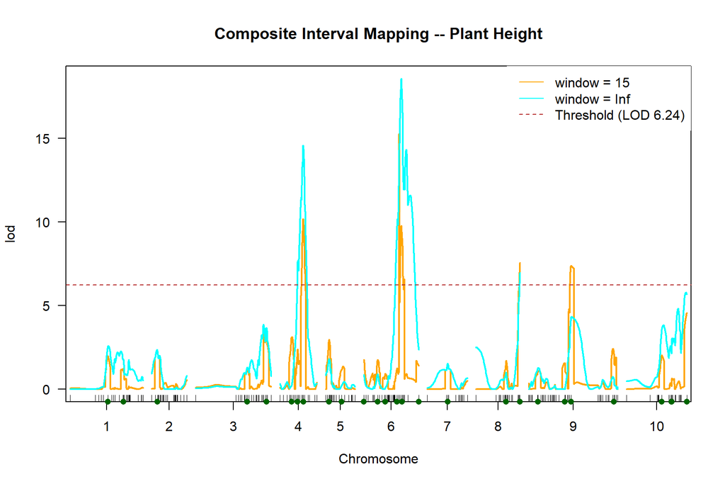

Figure 12. Composite interval mapping LOD profiles across all 10 linkage groups, comparing window = 15 cM (orange) and window = infinite (cyan) cofactor exclusion settings. The dashed red line marks the genome-wide significance threshold (LOD 6.24, alpha = 0.05). Green ticks mark positions of marker cofactors selected for the window = 15 scan.

```r
# both CIM window scans overlaid, threshold drawn as a horizontal
# line, green ticks via add.cim.covar() showing where the window = 15
# cofactors were picked - comparing window settings visually makes it
# obvious which peaks are stable vs sensitive to the window choice

plot(
  z020.cim15, z020.cimInf,
  col  = c("orange", "cyan"),
  main = "Composite Interval Mapping -- Plant Height"
)

add.threshold(
  z020.cim15,
  perms = z020.perm.cim,
  alpha = 0.05,
  col   = "firebrick",
  lty   = 2
)

add.cim.covar(z020.cim15, col = "darkgreen")

legend(
  "topright",
  legend = c("window = 15", "window = Inf", "Threshold (LOD 6.24)"),
  lty    = c(1, 1, 2),
  col    = c("orange", "cyan", "firebrick"),
  box.col = NA
)
```